# Health and Economic Effects of Severe Weather Events

Daniel DeWaters

10/14/2019

### Synopsis

This study seeks to answer two questions: Of the weather event types listed in the National Weather Service storm data set, which types have the greatest economic consequences and which are most harmful to population health? I chose to answer these questions by calculating the total property and crop damage costs from each weather event type using the “PROPDMG”, “PROPDMGEXP”, “CROPDMG”, “CROPDMGEXP” columns in the data set. I then calculated the total fatalities and injuries from each weather event type using the “FATALITIES” and “INJURIES” columns. I took the greatest 10 weather event types from all of these variables and plotted them on a barplot using ggplot2. I chose to calculate the *total* property and crop damage costs, fatalities, and injuries for each type over the averages because I think it is better to prepare for weather events that are costly *and* frequent, therefore allowing us to save more lives and money from damages over time.

## 1. Getting the Data

I start by downloading the data file, unzipping it, and reading it in using read.csv().

```r
# File URL/paths
data_url <- "https://d396qusza40orc.cloudfront.net/repdata%2Fdata%2FStormData.csv.bz2"
data_file_name <- "./data/repdata_data_StormData.csv.bz2"
unzipped_file_name <- "./data/repdata_data_StormData.csv"

# Download file if it does not exist
if(!file.exists(unzipped_file_name)){
  download.file(data_url, destfile=data_file_name, method="curl")
  bunzip2(data_file_name, destname=unzipped_file_name, remove=FALSE, overwrite=TRUE)
}

# Read in data
raw_data <- read.csv(unzipped_file_name)
```

## 2. Data Processing

### a. Cleaning

Cleaning the dataset was quite a process. There are a lot of different EVTYPE entries for the same type of weather event but use different phrasing or have abbreviations or spelling errors. This part of the preprocessing aims to group together as many of these event types as possible. Combining most of these event types ultimately did not matter in the final results, but in the future if there is some other analysis I want to run on the data set, a large portion of the cleaning will already be done.

This chunk also processes the property and crop damage columns by replacing the PROPDMGEXP and PROPDMGEXP with their respective exponent and multiplying the PROPDMG and CROPDMG columns by 10 to the power of their corresponding exponents.

After that is finished, I remove all event types that have less than 10 records in the data set. I chose to do this because I think each event type should have a decent sample size. Also, the types with less than 10 records are either too complex to categorize or have a typo that would add several lines to my already lengthy cleaning process.

```r
clean_data <-
  raw_data %>%

  ## Clean EVTYPE columns
  mutate(EVTYPE = tolower(EVTYPE)) %>%
  # Remove forward slashes and numbers at the end of types
  mutate(EVTYPE = gsub("/", " ", EVTYPE)) %>%
  mutate(EVTYPE = gsub(".\\d+$", "", EVTYPE)) %>%
  # Combine thunderstorm word variants
  mutate(EVTYPE = gsub("tstm", "thunderstorm", EVTYPE)) %>%
  mutate(EVTYPE = gsub("(.*)^thu(.*) *", "thunderstorm", EVTYPE)) %>%
  mutate(EVTYPE = gsub("thunderstorms", "thunderstorm", EVTYPE)) %>%
  mutate(EVTYPE = gsub("(.*)thunderstorm wind(.*)", "thunderstorm wind", EVTYPE)) %>%
  mutate(EVTYPE = gsub("\\d+ mph", "", EVTYPE)) %>%
  # Fix "wind" variants
  mutate(EVTYPE = gsub("wnd", "wind", EVTYPE)) %>%
  mutate(EVTYPE = gsub("winds", "wind", EVTYPE)) %>%
  # Combine all types about flooding, hurricanes, wind, landslide, hail, snow, and fire
  mutate(EVTYPE = gsub("fld", "flood", EVTYPE)) %>%
  mutate(EVTYPE = gsub("(.*)flood(.*)", "flood", EVTYPE)) %>%
  mutate(EVTYPE = gsub("(.*)surf(.*)", "heavy surf", EVTYPE)) %>%
  mutate(EVTYPE = gsub("(.*)hurricane(.*)", "hurricane", EVTYPE)) %>%
  mutate(EVTYPE = gsub("(.*)tropical storm(.*)", "tropical storm", EVTYPE)) %>%
  mutate(EVTYPE = gsub("(.*)high wind(.*)", "high wind", EVTYPE)) %>%
  mutate(EVTYPE = gsub("(.*)land(.*)", "landslide", EVTYPE)) %>%
  mutate(EVTYPE = gsub("(.*)slide(.*)", "landslide", EVTYPE)) %>%
  mutate(EVTYPE = gsub("(.*)water *spout(.*)", "waterspout", EVTYPE)) %>%
  mutate(EVTYPE = gsub("(.*)wind *chill(.*)", "wind chill", EVTYPE)) %>%
  mutate(EVTYPE = gsub("(.*)hail(.*)", "hail", EVTYPE)) %>%
  mutate(EVTYPE = gsub("(.*)snow(.*)", "snow", EVTYPE)) %>%
  mutate(EVTYPE = gsub("(.*)fire(.*)", "wildfire", EVTYPE)) %>%
  # Fix "tornado" misspellings
  mutate(EVTYPE = gsub("(.*)torn(.*)", "tornado", EVTYPE)) %>%
  # Other
  mutate(EVTYPE = gsub("unseason(.*) ", "unseasonal ", EVTYPE)) %>%
  mutate(EVTYPE = gsub("(.*)heat(.*)|(.*)hot(.*)|(.*)warm(.*)", "heat", EVTYPE)) %>%
  mutate(EVTYPE = gsub("(.*)cold(.*)|(.*)cool(.*)", "cold", EVTYPE)) %>%
  mutate(EVTYPE = gsub("(.*)freeze(.*)", "freeze", EVTYPE)) %>%
  mutate(EVTYPE = gsub("(.*)freezing rain(.*)", "freezing rain", EVTYPE)) %>%
  mutate(EVTYPE = gsub("^(?!freezing)(.*)rain(.*)", "rain", EVTYPE, perl=TRUE)) %>%
  filter(!grepl("summary", EVTYPE)) %>%

  ## Clean property and crop damage and exponents columns
  mutate(PROPDMGEXP = tolower(PROPDMGEXP)) %>%
  mutate(CROPDMGEXP = tolower(CROPDMGEXP)) %>%
  # Replace exponent characters with the corresponding number
  mutate(PROPDMGEXP = revalue(PROPDMGEXP, replace=c("-"="0", "?"="0", "+"="1", "h"="2", "k"="3", "m"="6", "b"="9"))) %>%
  mutate(CROPDMGEXP = revalue(CROPDMGEXP, replace=c("?"="0", "k"="3", "m"="6", "b"="9"))) %>%
  # revalue doesn't replace blank strings so I had to do it this way
  mutate(PROPDMGEXP = gsub("^$", "0", PROPDMGEXP)) %>%
  mutate(CROPDMGEXP = gsub("^$", "0", CROPDMGEXP)) %>%
  # Convert exponents to numeric
  mutate(PROPDMGEXP = as.numeric(PROPDMGEXP)) %>%
  mutate(CROPDMGEXP = as.numeric(CROPDMGEXP)) %>%
  # multiply damage and exponent columns to get full damages
  mutate(propertydamage = PROPDMG * (10^PROPDMGEXP)) %>%
  mutate(cropdamage = CROPDMG * (10^CROPDMGEXP))


## Filter by event types that have more than 10 records in the dataset
# Get all evtypes and count the frequency of each type in dataset
ev_type_counts <- sort(table(clean_data$EVTYPE), decreasing=TRUE)
# Convert table to dataframe for ease of sorting by frequency
ev_df <- as.data.frame(ev_type_counts, stringsAsFactors=FALSE); names(ev_df) <- c("type", "freq")
# Get list of evtypes that have more than 10 records in dataset
top_counts <- filter(ev_df, freq >= 10)
# Get records from dataset that occur in list of evtypes that show up more than 10 times
data <- filter(clean_data, EVTYPE %in% top_counts$type)
```

### b. Calculations

```r
## Get the average and total property/crop damage for each event type,
## then the average and total deaths and injuries for each event type
data_means <-
  data %>%
  group_by(EVTYPE) %>%
  summarise(sum_prop_dmg = sum(propertydamage, na.rm=TRUE),
            sum_crop_dmg = sum(cropdamage, na.rm=TRUE),
            total_dmg = sum_prop_dmg + sum_crop_dmg,
            sum_injuries = sum(INJURIES, na.rm = TRUE),
            sum_fatalities = sum(FATALITIES, na.rm=TRUE))



## Get the top 10 highest-costing weather event types for total
## and average property and crop damages
top_total_dmg <-
  data_means %>%
  # Select columns that we want to plot
  select(EVTYPE, total_dmg, sum_prop_dmg, sum_crop_dmg) %>%
  # Sort by the top 10 highest total costs
  arrange(desc(total_dmg)) %>%
  top_n(10, sum_crop_dmg) %>%
  # Change column names for ease of plotting
  rename("Property"="sum_prop_dmg", "Crop"="sum_crop_dmg") %>%
  # Remove total_dmg column for ease of plotting
  select(EVTYPE, Crop, Property)

# Melt data frame into narrow form for ease of plotting
top_dmg <- melt(top_total_dmg,
            id.vars="EVTYPE", measure.vars=c("Crop", "Property"),
            value.name = "cost")
top_dmg <- rename(top_dmg, "Damage"="variable")

# Makes ggplot2 plot the barplots in decreasing order
dmg_order <- top_total_dmg$EVTYPE
top_dmg$EVTYPE <- factor(top_dmg$EVTYPE, levels=dmg_order)



## Get the top 10 highest fatal and injuring weather event types
top_fatal <-
  data_means %>%
  select(EVTYPE, sum_fatalities) %>%
  arrange(desc(sum_fatalities)) %>%
  top_n(10, sum_fatalities) %>%
  rename("Fatalities"="sum_fatalities")

top_injury <-
  data_means %>%
  select(EVTYPE, sum_injuries) %>%
  arrange(desc(sum_injuries)) %>%
  top_n(10, sum_injuries) %>%
  rename("Injuries"="sum_injuries")
```

## 3. Results

### a. Economic Consequences

The largest economic-affecting weather event type is “flood” with its property and crop damage costs totaling at $180,659,067,883. The majority of the damage costs are from property damage.

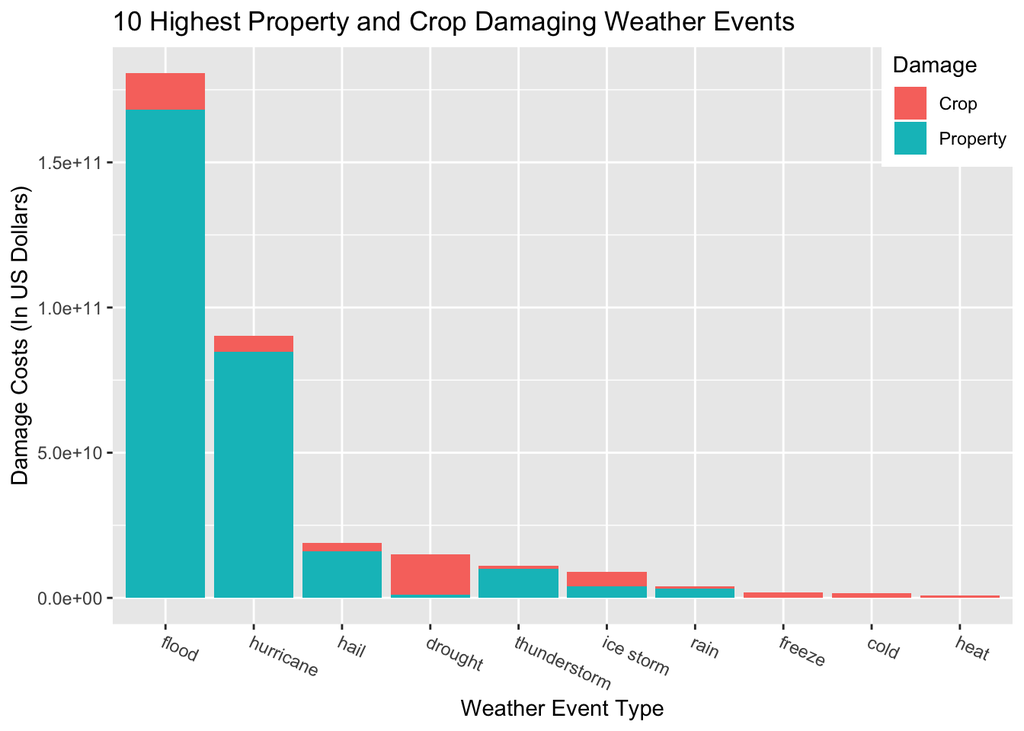

```r
# Make plot for total damages made by each weather event type
dmg_plot <- ggplot(top_dmg, aes(fill=Damage, x=EVTYPE, y=cost))
dmg_plot + geom_bar(position="stack", stat="identity") +
  xlab("Weather Event Type") + ylab("Damage Costs (In US Dollars)") +
  ggtitle("10 Highest Property and Crop Damaging Weather Events") +
  theme(legend.position=c(.93, .9)) + theme(axis.text.x=element_text(angle=-25, hjust=0))
```

### b. Population Health Consequences

The weather event with the largest effect to human health is “tornado”, with a total number of 5,633 fatalities and 91,364 injuries.

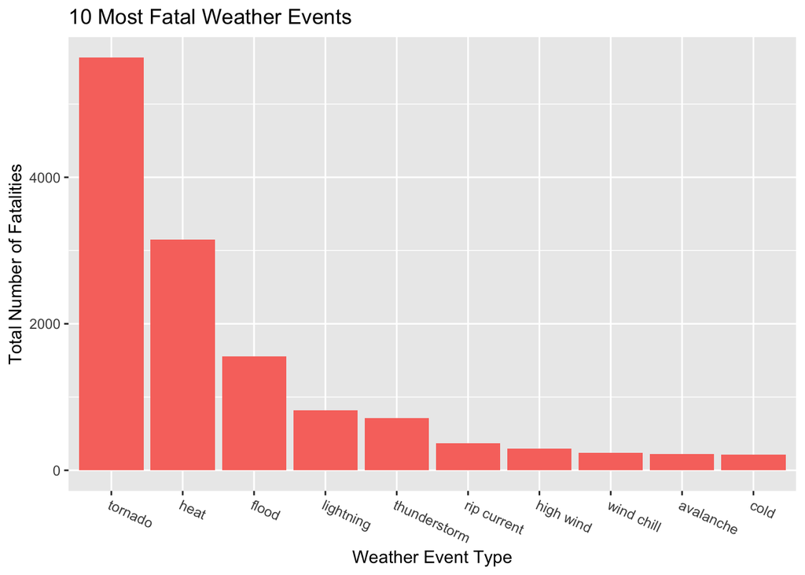

```r
# Make plot for total fatalities by each weather event type
fatal_plot <- ggplot(top_fatal, aes(x=reorder(EVTYPE, -Fatalities), y=Fatalities))
fatal_plot + geom_bar(stat="identity", fill="#F8766D") +
  xlab("Weather Event Type") + ylab("Total Number of Fatalities") +
  ggtitle("10 Most Fatal Weather Events") +
  theme(axis.text.x=element_text(angle=-25, hjust=0))
```

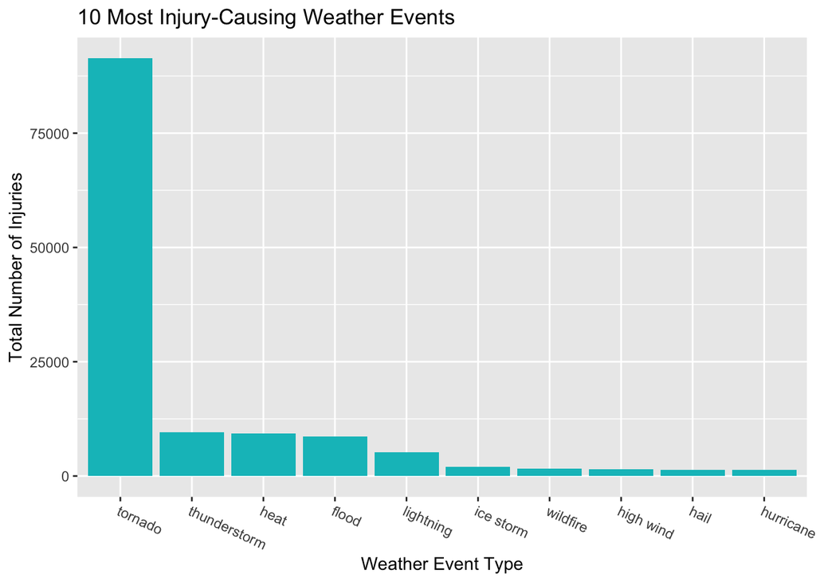

```r
# Make plot for total injuries by each weather event type
injury_plot <- ggplot(top_injury, aes(x=reorder(EVTYPE, -Injuries), y=Injuries))
injury_plot + geom_bar(stat="identity", fill="#00BFC4") +
  xlab("Weather Event Type") + ylab("Total Number of Injuries") +
  ggtitle("10 Most Injury-Causing Weather Events") +
  theme(axis.text.x=element_text(angle=-25, hjust=0))
```